# Final_Week3_R_Assignment

Divya Purohith

November 7, 2018

1. Please Do the following DataCamp activities. The first two chapters of Writing Functions in R. The whole course on “Introduction to the Tidyverse”
2. Read in the .csv file (call it rna_counts).

# read .csv file and call it rna_counts

```r
rna_counts <- read.csv("./eXpress_dm_counts.csv", row.names=1)
```

*DONE*: Write a function that calculates and can output mean expression (using the mean() function) for a given data column.

*DONE*: Write this function so that it can work on either raw counts (as provided) or transformed to log2 values of the counts, with a logical argument that allows the user to choose whether to do this on the raw scale or log2 scale (i.e. log2 transform, then calculate the mean). CHECK at end: Make sure all functions you write for this assignment have this argument. We often use log2 scale for RNAseq data. *DONE*: Demonstrate that it works on several of the columns of data.

```r
compute_mean <- function(columnData, isLog2 = FALSE) {
  #column_data = rna_counts[,columnIndex];
  mean_value = NA;
  if(isLog2 ==TRUE){
    log2_values = log2(columnData)
    log2_values <-  log2_values[is.finite(log2(columnData))] #remove -Inf.
    mean_value = mean(log2_values, na.rm = TRUE)
  }else{
    mean_value <- mean(columnData, na.rm = TRUE);
  }
  return(mean_value)
}
```

# Example of some random numbers to see if the function worked

```r
#compute_mean(rna_counts[,1], isLog2 = FALSE);
compute_mean( rna_counts[,"F101_lg_female_hdhorn"], isLog2 = FALSE)
```

```
## [1] 1978.847
```

```r
compute_mean(rna_counts[,1], isLog2 = TRUE)
```

```
## [1] 9.033518
```

```r
compute_mean(rna_counts[,2], isLog2 = TRUE)
```

```
## [1] 9.045379
```

3. Now using the function you have written, Task1 DONE: use a loop to generate a vector of the mean expression value for each column (each sample).

*Task2 DONE*: Make sure that your output vector have named elements (i.e. each element of the vector is associated with the names of the original columns of the data).

*Task2 analyse*: Do you notice any patterns for which individuals or tissues have the highest mean expression?

```r
compute_matrix_col_mean_loop = function(matrix, isLog2 = FALSE){
  outVector = NULL;
  if(isLog2==FALSE){
  for( col in 1 :ncol(matrix)) {
    key = colnames(matrix)[col]
    value = compute_mean(matrix[,col],isLog2)
    names(value) <- key
    outVector <- c(outVector, value)
  }
  return( outVector)
  }else{

    #TRANSFORMED VALUES
  }
}

meanFromLoop <- compute_matrix_col_mean_loop(rna_counts, isLog2 = TRUE)

na.omit(meanFromLoop)
```

[output not shown]

```r
#compute_matrix_mean_loop(rna_counts, isLog2 = TRUE)
```

4. Repeat this procedure (using the function you wrote, or slightly revised) that uses one of the apply family of functions to do the same as 3. Check which is faster (to compute not to write), and demonstrate how you did this.

```r
compute_matrix_col_mean = function(matrix, isLog2 = FALSE){
     apply(matrix,2, compute_mean, isLog2)
}
meanFromApply <- compute_matrix_col_mean(rna_counts, isLog2 = TRUE)

#check same
identical(meanFromLoop, meanFromApply)
```

```
## [1] FALSE
```

```r
#sort(matrixMean)
#compute_matrix_mean(rna_counts, isLog2 = TRUE)

#check which one is faster' -- loop is faster, apply is slower.
system.time(replicate(1000,compute_matrix_col_mean_loop(rna_counts, isLog2 = TRUE)))
```

```
##    user  system elapsed
##    0.01    0.00    0.02
```

```r
system.time(replicate(1000,compute_matrix_col_mean(rna_counts, isLog2 = TRUE)))
```

```
##    user  system elapsed
##   44.33    0.61   45.42
```

```
#> system.time(replicate(1000,compute_matrix_mean_loop(rna_counts, isLog2 = TRUE)))
```

```r
#   user  system elapsed
# 19.23    0.00   19.44
```

```
#> system.time(replicate(1000,compute_matrix_mean(rna_counts, isLog2 = TRUE)))
```

```r
#    user  system elapsed
# 29.64    0.45   30.14
```

5. What is a much easier way to do the operations we did in Q 3 and 4, (i.e. you don’t need to write your own function) to calculate and output all of the column means? i.e. an Rish way of doing this?

# much way easier way to do means of all the columns

```r
colMeans(rna_counts)
```

```
##  F101_lg_female_hdhorn F101_lg_female_thxhorn   F101_lg_female_wings
##               1978.847               1983.250               1583.904
##  F105_lg_female_hdhorn F105_lg_female_thxhorn   F105_lg_female_wings
##               2105.712               1433.749               1869.962
##  F131_lg_female_hdhorn F131_lg_female_thxhorn   F131_lg_female_wings
##               2117.847               2307.529               2272.692
##   F135_sm_female_wings  F135_sm_female_hdhorn F135_sm_female_thxhorn
##               1728.483               1452.913               1776.309
##  F136_sm_female_hdhorn F136_sm_female_thxhorn   F136_sm_female_wings
##               2065.780               1777.769               1988.882
##  F196_sm_female_hdhorn F196_sm_female_thxhorn   F196_sm_female_wings
##               1348.898               1025.301               3067.287
##  F197_sm_female_hdhorn F197_sm_female_thxhorn   F197_sm_female_wings
##               2639.152               2047.151               2081.889
##  F218_lg_female_hdhorn F218_lg_female_thxhorn   F218_lg_female_wings
##               2329.563               1950.561               2074.992
## M120_sm_male_genitalia    M120_sm_male_hdhorn   M120_sm_male_thxhorn
##               1832.780               2105.145               2101.163
##     M120_sm_male_wings M125_lg_male_genitalia    M125_lg_male_hdhorn
##               2536.920               2088.092               2372.259
##     M125_lg_male_wings M160_lg_male_genitalia    M160_lg_male_hdhorn
##               2559.085               1727.538               2111.337
##   M160_lg_male_thxhorn     M160_lg_male_wings M171_sm_male_genitalia
##               2087.583               2184.076               2035.093
##    M171_sm_male_hdhorn   M171_sm_male_thxhorn     M171_sm_male_wings
##               1598.190               1621.659               1825.344
## M172_sm_male_genitalia    M172_sm_male_hdhorn   M172_sm_male_thxhorn
##               2196.101               1713.119               1344.019
##     M172_sm_male_wings M180_lg_male_genitalia    M180_lg_male_hdhorn
##               2602.351               1922.634               2670.498
##   M180_lg_male_thxhorn     M180_lg_male_wings M200_sm_male_genitalia
##               2003.293               3216.476               2412.038
##    M200_sm_male_hdhorn   M200_sm_male_thxhorn     M200_sm_male_wings
##               2032.085               2820.495               2203.813
## M257_lg_male_genitalia    M257_lg_male_hdhorn   M257_lg_male_thxhorn
##               2170.258               2361.912               2749.767
##     M257_lg_male_wings
##               1325.684
```

```r
 # The disadvantage is, this one does not have isLog2 option.
```

6. It is common (say for a MAplot) to want the mean expression value of each given gene across all samples. Write a function to do this, and using one of the approaches from Q 3-5 generate and store these values in a variable.

```r
compute_matrix_row_mean = function(matrix, isLog2 = FALSE){
     apply(matrix,1, compute_mean, isLog2)
}

gene_mean_expression = compute_matrix_row_mean(rna_counts)
head(gene_mean_expression) #same gene, accross samples.
```

```
## FBpp0087248 FBpp0293785 FBpp0080383 FBpp0077879 FBpp0311746 FBpp0289081
##    23.45455  3446.90909    79.54545   139.21818   145.09091  1485.90909
```

7. We are very interested in what is going on in the head horns between small males and large males. Using the type of tools you have written (feel free to modify as you need, but show the new functions) calculate the mean expression for the subset of columns for large and small male head horns. Note you are calculating means on a gene by gene basis, NOT sample by sample. Now calculate the mean difference (again gene by gene) between large male and small males (for head horns). i.e. first calculate the mean expression among individuals who are large males (head horns), ditto for the small males, and calculate their difference.

# grep function to extract sm_male_hdhorn

```r
sm_male_hdhorn <- rna_counts[,grep("sm_male_hdhorn",colnames(rna_counts))]
```

# grep function to extract lg_male_hdhorn

```r
lg_male_hdhorn <- rna_counts[,grep("lg_male_hdhorn",colnames(rna_counts))]
lg_male_hdhorn
```

[output not shown]

[output cut: 8697 more lines]

[output not shown]

# gene_mean_expression for sm_male_hdhorn

```r
compute_matrix_row_mean = function(matrix, isLog2 = FALSE){
     apply(matrix,1, compute_mean, isLog2)
}

sm_gene_mean_expression = compute_matrix_row_mean(sm_male_hdhorn)
head(gene_mean_expression) #same gene, accross samples.
```

```
## FBpp0087248 FBpp0293785 FBpp0080383 FBpp0077879 FBpp0311746 FBpp0289081
##    23.45455  3446.90909    79.54545   139.21818   145.09091  1485.90909
```

# gene_mean_expression for lg_male_hdhorn

```r
compute_matrix_row_mean = function(matrix, isLog2 = FALSE){
  apply(matrix,1, compute_mean, isLog2)
}

lg_gene_mean_expression = compute_matrix_row_mean(lg_male_hdhorn)
head(gene_mean_expression) #same gene, accross samples.
```

```
## FBpp0087248 FBpp0293785 FBpp0080383 FBpp0077879 FBpp0311746 FBpp0289081
##    23.45455  3446.90909    79.54545   139.21818   145.09091  1485.90909
```

# head and tail of small and large male headhorn to see if it worked

```r
head(lg_gene_mean_expression)
```

```
## FBpp0087248 FBpp0293785 FBpp0080383 FBpp0077879 FBpp0311746 FBpp0289081
##       21.25     6722.50       66.00        6.25      145.00     1159.50
```

```r
tail(lg_gene_mean_expression)
```

```
## FBpp0071461 FBpp0071459 FBpp0292237 FBpp0073029 FBpp0073200 FBpp0303833
##     6440.50      939.25       96.00      673.50        7.25      427.25
```

```r
head(sm_gene_mean_expression)
```

```
## FBpp0087248 FBpp0293785 FBpp0080383 FBpp0077879 FBpp0311746 FBpp0289081
##       37.50     3313.25       71.75       22.50      119.00     1179.00
```

```r
tail(sm_gene_mean_expression)
```

```
## FBpp0071461 FBpp0071459 FBpp0292237 FBpp0073029 FBpp0073200 FBpp0303833
##     3969.50      710.25       75.50      601.25        4.00      427.50
```

# difference between lg_male_horn and sm_male_horn

```r
diff <- cbind(lg_gene_mean_expression - sm_gene_mean_expression)
tail(diff)
```

```
##                [,1]
## FBpp0071461 2471.00
## FBpp0071459  229.00
## FBpp0292237   20.50
## FBpp0073029   72.25
## FBpp0073200    3.25
## FBpp0303833   -0.25
```

8. Using the basic plot function (although you can use ggplot2 if you prefer), plot the mean expression of each gene on the X axis, and the difference in expression values on the Y axis. Now repeat, but with log2 transformed data. This is the basic idea of a MAplot.

# basic plot of mean expression of each gene on X axis & difference in expression values on Y axis

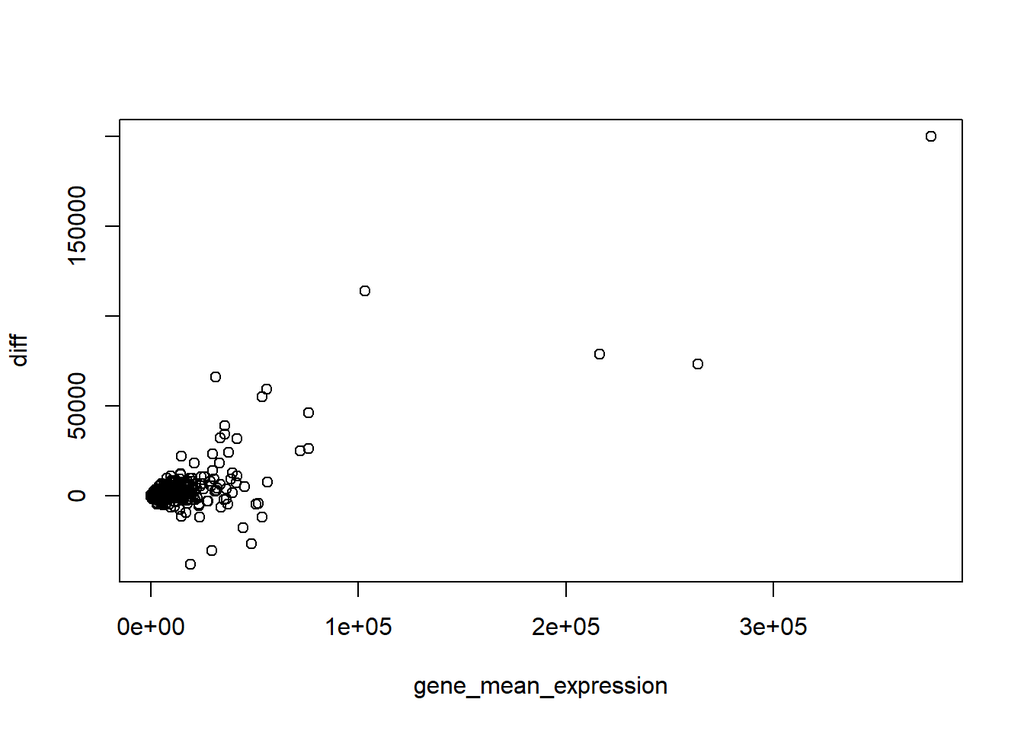

```r
plot(gene_mean_expression, diff)
```

```r
#I donot understand why it shows the positive values
```

# ggplot for gene expression

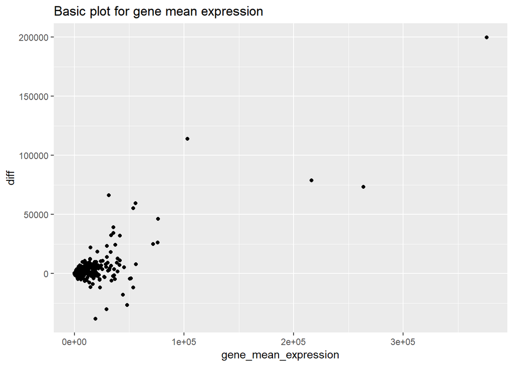

```r
require(ggplot2)
ggplot(data = rna_counts, aes(x = gene_mean_expression, y = diff)) +
  geom_point() +
  labs(title = "Basic plot for gene mean expression")
```

# log2 transformations of mean gene expressions and difference of expreesion values

```r
log2_gene_mean_expression <- log2(gene_mean_expression) #remove -Inf
log2_diff_mean_expression <- log2(diff) #remove -Inf
```

# basic plot of log2 transformed values

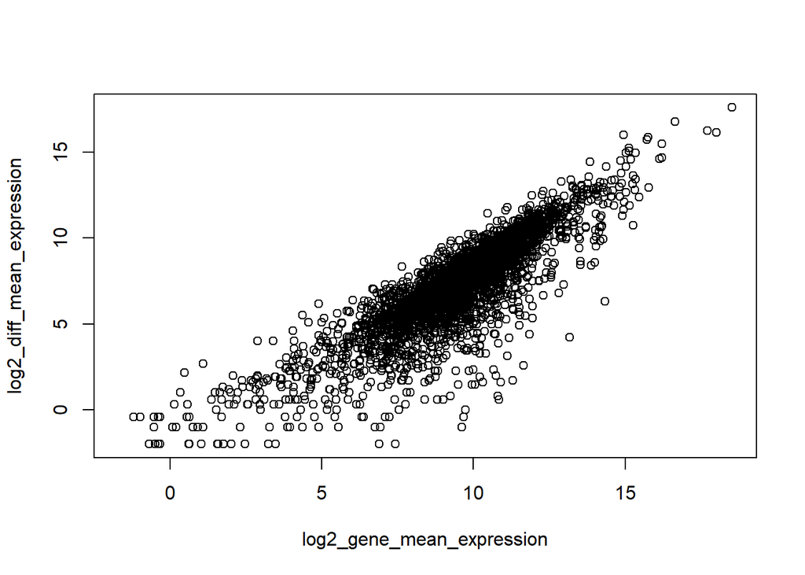

```r
plot(x = log2_gene_mean_expression, y = log2_diff_mean_expression)
```

# ggplot for gene expression

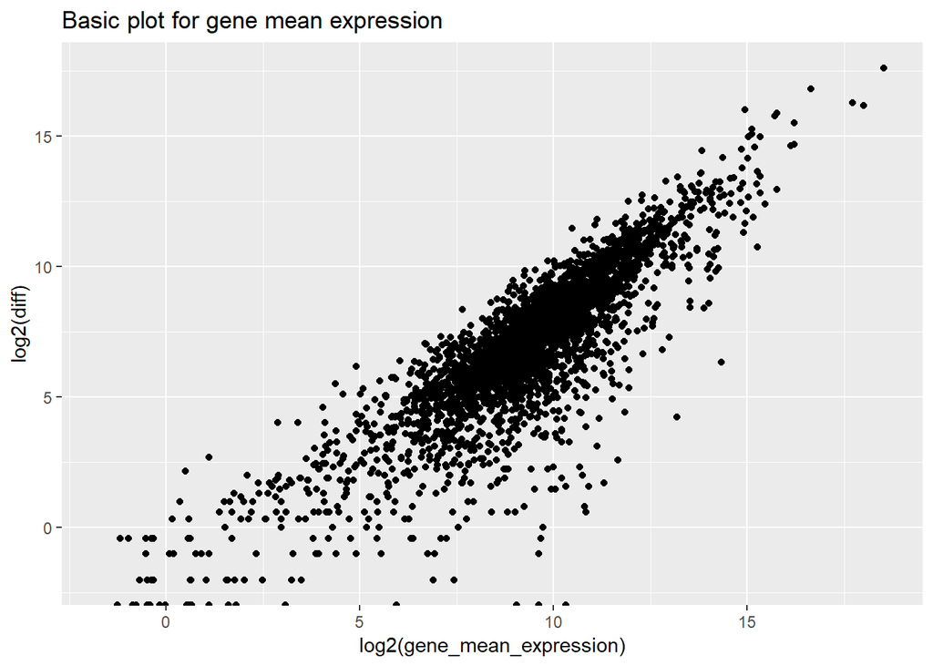

```r
ggplot(data = rna_counts, aes(x = log2(gene_mean_expression), y = log2(diff))) +
  geom_point() +
  labs(title = "Basic plot for gene mean expression")
```

# Bonus question. What other way might you be able to do these operations (could be a tidyverse way, or a more Rish vectorized way)?